**City College of San Francisco**

MATH 108 - Foundations of Data Science

# Lecture 26: The Normal Curve

Associated Textbook Sections: [14.3, 14.4](https://inferentialthinking.com/chapters/14/3/SD_and_the_Normal_Curve.html)

## Set Up the Notebook

```python
from datascience import *
import numpy as np
%matplotlib inline
import matplotlib.pyplot as plots
plots.style.use('fivethirtyeight')
```

# Table of Contents

## Chebyshev's Inequality

### How Big are Most of the Values?

- No matter what the shape of the distribution, the bulk of the data are in the range "average ± a few SDs"
- Chebyshev’s Inequality
  - No matter what the shape of the distribution, the proportion of values in the range "average ± $z$ SDs" is **at least** $1 - 1/z^2$

### Chebyshev's Bounds

No matter what the distribution looks like, the proportion of data values follows:

[figure not shown]

### Demo: Chebyshev's Bound

Explore a demonstration of Chebyshev's bounds through a data set.

```python
births = Table.read_table('baby.csv')
births.show(3)
```

| Birth Weight | Gestational Days | Maternal Age | Maternal Height | Maternal Pregnancy Weight | Maternal Smoker |
| --- | --- | --- | --- | --- | --- |
| 120 | 284 | 27 | 62 | 100 | False |
| 113 | 282 | 33 | 64 | 135 | False |
| 128 | 279 | 28 | 64 | 115 | True |

... (1171 rows omitted)

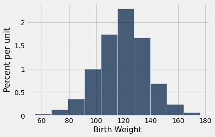

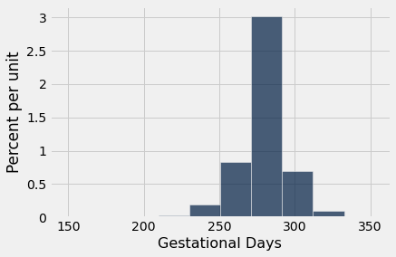

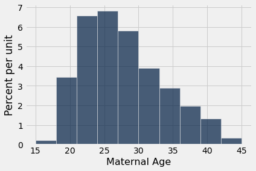

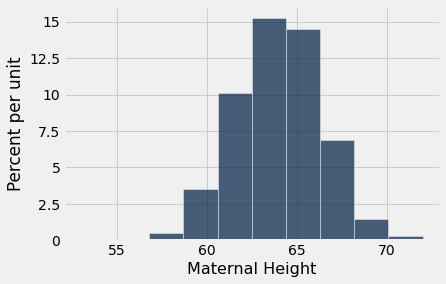

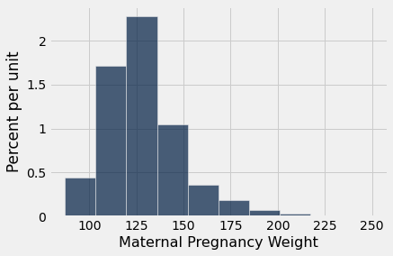

```python
for i in np.arange(5):
    births.hist(i)
```

```python
mpw = births.column('Maternal Pregnancy Weight')
mean = np.mean(mpw)
sd = np.std(mpw)
mean, sd
```

```
(128.4787052810903, 20.72544970428041)
```

```python
within_3_SDs = births.where('Maternal Pregnancy Weight', are.between(mean - 3*sd, mean + 3*sd))
```

```python
# Proportion within 3 SDs of the mean

within_3_SDs.num_rows / births.num_rows
```

```
0.9863713798977853
```

```python
# Chebyshev's bound:
# The proportion we calculated above should be at least

1 - 1/(3**2)
```

```
0.8888888888888888
```

```python
births.labels
```

[output not shown]

```python
# See if Chebyshev's bounds work for distributions with various shapes

for feature in births.labels:
    values = births.column(feature)
    mean = np.mean(values)
    sd = np.std(values)
    print()
    print(feature)
    for z in make_array(2, 3, 4, 5):
        chosen = births.where(feature, are.between(mean - z*sd, mean + z*sd))
        proportion = chosen.num_rows / births.num_rows
        percent = round(proportion * 100, 2)
        print('Average plus or minus', z, 'SDs:', percent, '% of the data')
```

```
Birth Weight
Average plus or minus 2 SDs: 94.89 % of the data
Average plus or minus 3 SDs: 99.57 % of the data
Average plus or minus 4 SDs: 100.0 % of the data
Average plus or minus 5 SDs: 100.0 % of the data

Gestational Days
Average plus or minus 2 SDs: 93.78 % of the data
Average plus or minus 3 SDs: 98.64 % of the data
Average plus or minus 4 SDs: 99.57 % of the data
Average plus or minus 5 SDs: 99.83 % of the data

Maternal Age
Average plus or minus 2 SDs: 94.89 % of the data
Average plus or minus 3 SDs: 99.91 % of the data
Average plus or minus 4 SDs: 100.0 % of the data
Average plus or minus 5 SDs: 100.0 % of the data

Maternal Height
Average plus or minus 2 SDs: 97.19 % of the data
Average plus or minus 3 SDs: 99.66 % of the data
Average plus or minus 4 SDs: 99.91 % of the data
Average plus or minus 5 SDs: 100.0 % of the data

Maternal Pregnancy Weight
Average plus or minus 2 SDs: 95.06 % of the data
Average plus or minus 3 SDs: 98.64 % of the data
Average plus or minus 4 SDs: 99.49 % of the data
Average plus or minus 5 SDs: 99.91 % of the data

Maternal Smoker
Average plus or minus 2 SDs: 100.0 % of the data
Average plus or minus 3 SDs: 100.0 % of the data
Average plus or minus 4 SDs: 100.0 % of the data
Average plus or minus 5 SDs: 100.0 % of the data
```

### Standard Units

- How many SDs above average?
- `z = (value - average)/SD`
  - Negative z: value below average
  - Positive z: value above average
  - z = 0: value equal to average
- When values are in standard units: average = 0, SD = 1
- Gives us a way to compare/understand data no matter what the original units

### Demo: Standard Units

Create a function to convert a measurement to standard units and apply it to the previous data set.

```python
def standard_units(x):
    """Convert array x to standard units."""
    return (x - np.mean(x)) / np.std(x)
```

```python
ages = births.column('Maternal Age')
ages
```

```
array([27, 33, 28, ..., 30, 21, 38])
```

```python
ages_standard_units = standard_units(ages)
```

```python
np.mean(ages_standard_units), np.std(ages_standard_units)
```

```
(-7.868020072300939e-17, 1.0)
```

```python
both = Table().with_columns(
    'Age in Years', ages,
    'Age in Standard Units', ages_standard_units
)
both
```

| Age in Years | Age in Standard Units |
| --- | --- |
| 27 | -0.0392546 |
| 33 | 0.992496 |
| 28 | 0.132704 |
| 23 | -0.727088 |
| 25 | -0.383171 |
| 33 | 0.992496 |
| 23 | -0.727088 |
| 25 | -0.383171 |
| 30 | 0.476621 |
| 27 | -0.0392546 |

... (1164 rows omitted)

```python
np.mean(ages) + np.std(ages)
```

```
33.04363979090299
```

```python
np.mean(ages), np.std(ages)
```

```
(27.228279386712096, 5.815360404190897)
```

Compare the distribution of values and standardized values.

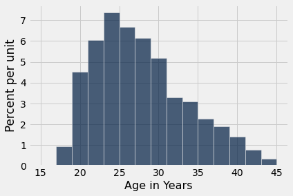

```python
both.hist('Age in Years', bins = np.arange(15, 46, 2))
```

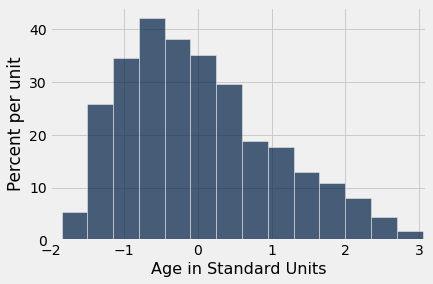

```python
both.hist('Age in Standard Units', bins = np.arange(-2.2, 3.4, 0.35))
plots.xlim(-2, 3.1);
```

### The SD and the Histogram

- Usually, it's not easy to estimate the SD by looking at a histogram.
- But if the histogram has a bell shape, then you can.

### The SD and Bell-Shaped Curves

If a histogram is bell-shaped, then

- the average is at the center
- the SD is the distance between the average and the points of inflection on either side

### Demo: The SD and Bell Shaped Curves

Notice the way the distribution changes around $\pm 1$ of the mean.

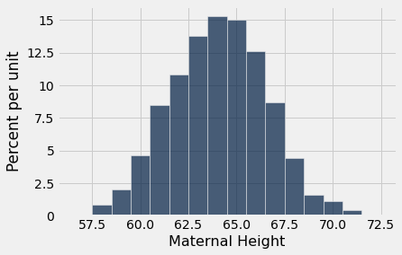

```python
births.hist('Maternal Height', bins = np.arange(56.5, 72.6, 1))
```

```python
heights = births.column('Maternal Height')
np.mean(heights), np.std(heights)
```

```
(64.04940374787053, 2.5250254409674375)
```

```python
np.mean(heights) + np.std(heights), np.mean(heights) - np.std(heights)
```

```
(66.57442918883797, 61.52437830690309)
```

### Point of Inflection

[figure not shown]

## The Normal Distribution

### Bell Curve(s)

There are many, many, many normal curves!

[figure not shown]

## Normal Proportions

### How Big are Most of the Values?

- No matter what the shape of the distribution, the bulk of the data are in the range "average ± a few SDs"
- If a histogram is bell-shaped, then almost all of the data are in the range "average ± 3 SDs"

### Bounds and Normal Approximations

[figure not shown]

### A "Central" Area

[figure not shown]